# Introduction Page

Kinito Solutions

September 11, 2016

# Introduction

R is a statistical software that is used for estimating econometrics models. For more information, please check the Official R website.

In this Introduction to R video, you will learn about how to use the R software to read data sets, do basic statistical analysis, and get familiar with the program so that we can use it for more sophisticated econometric models. You will also learn about R studio, a user-friendly interface to use with R.

R studio – R user interface Advantages and disadvantages of R Programs – R program file (.R) R Console – where commands are listed and results are shown Data files – csv files Importing data – read, attach Summarizing and analyzing data – summary, sort, table, cor Statistical analysis (t test, anova, regressions) – t.test, anova, olsreg Install and use packages Using help

# Introduction Example

This uses multiple independent variables in the lm-function. This is easily achieved by separating each exogenous variable that should enter the model with a plus sign (e.g. lm(colGPA ~ hsGPA + ACT)).

```r
myDataFrame <- read.csv("Data/intro_auto.csv")
head(myDataFrame)
```

```
##   make price mpg repairs weight length foreign
## 1  AMC  4099  22       3   2930    186       0
## 2  AMC  4749  17       3   3350    173       0
## 3  AMC  3799  22       3   2640    168       0
## 4 Audi  9690  17       5   2830    189       1
## 5 Audi  6295  23       3   2070    174       1
## 6  BMW  9735  25       4   2650    177       1
```

```r
attach(myDataFrame)
# List the variables
names(myDataFrame)
```

```
## [1] "make"    "price"   "mpg"     "repairs" "weight"  "length"  "foreign"
```

```r
# Show first lines of data
head(myDataFrame)
```

```
##   make price mpg repairs weight length foreign
## 1  AMC  4099  22       3   2930    186       0
## 2  AMC  4749  17       3   3350    173       0
## 3  AMC  3799  22       3   2640    168       0
## 4 Audi  9690  17       5   2830    189       1
## 5 Audi  6295  23       3   2070    174       1
## 6  BMW  9735  25       4   2650    177       1
```

```r
myDataFrame[1:10,]
```

```
##     make price mpg repairs weight length foreign
## 1    AMC  4099  22       3   2930    186       0
## 2    AMC  4749  17       3   3350    173       0
## 3    AMC  3799  22       3   2640    168       0
## 4   Audi  9690  17       5   2830    189       1
## 5   Audi  6295  23       3   2070    174       1
## 6    BMW  9735  25       4   2650    177       1
## 7  Buick  4816  20       3   3250    196       0
## 8  Buick  7827  15       4   4080    222       0
## 9  Buick  5788  18       3   3670    218       0
## 10 Buick  4453  26       3   2230    170       0
```

```r
# Descriptive statistics
summary(mpg)
```

```
##    Min. 1st Qu.  Median    Mean 3rd Qu.    Max.
##   14.00   17.25   21.00   20.92   23.00   35.00
```

```r
sd(mpg)
```

```
## [1] 4.757504
```

```r
length(mpg)
```

```
## [1] 26
```

```r
summary(price)
```

```
##    Min. 1st Qu.  Median    Mean 3rd Qu.    Max.
##    3299    4466    5146    6652    8054   15910
```

```r
sd(price)
```

```
## [1] 3371.12
```

```r
# Sort the data
sort(make)
```

```
##  [1] AMC       AMC       AMC       Audi      Audi      BMW       Buick
##  [8] Buick     Buick     Buick     Buick     Buick     Buick     Cadillac
## [15] Cadillac  Cadillac  Chevrolet Chevrolet Chevrolet Chevrolet Chevrolet
## [22] Chevrolet Datsun    Datsun    Datsun    Datsun
## Levels: AMC Audi BMW Buick Cadillac Chevrolet Datsun
```

```r
# Frequency tables
table(make)
```

```
## make
##       AMC      Audi       BMW     Buick  Cadillac Chevrolet    Datsun
##         3         2         1         7         3         6         4
```

```r
table(make, foreign)
```

```
##            foreign
## make        0 1
##   AMC       3 0
##   Audi      0 2
##   BMW       0 1
##   Buick     7 0
##   Cadillac  3 0
##   Chevrolet 6 0
##   Datsun    0 4
```

```r
# Correlation among variables
cor(price, mpg)
```

```
## [1] -0.4384618
```

```r
# T-test for mean of one group
t.test(mpg, mu=20)
```

```
##
##  One Sample t-test
##
## data:  mpg
## t = 0.98934, df = 25, p-value = 0.332
## alternative hypothesis: true mean is not equal to 20
## 95 percent confidence interval:
##  19.00148 22.84467
## sample estimates:
## mean of x
##  20.92308
```

```r
# linear model of 2 groups
linearModel <- lm(mpg ~ factor(foreign))
# ANOVA for equality of means for two groups
anova(linearModel)
```

```
## Analysis of Variance Table
##
## Response: mpg
##                 Df Sum Sq Mean Sq F value Pr(>F)
## factor(foreign)  1  90.69  90.688  4.5806 0.0427 *
## Residuals       24 475.16  19.798
## ---
## Signif. codes:  0 '***' 0.001 '**' 0.01 '*' 0.05 '.' 0.1 ' ' 1
```

```r
# OLS regression - mpg (dependent variable) and weight, length and foreign (independent variables)
olsreg <- lm(mpg ~ weight + length + foreign)
summary(olsreg)
```

```
##
## Call:
## lm(formula = mpg ~ weight + length + foreign)
##
## Residuals:
##     Min      1Q  Median      3Q     Max
## -4.3902 -1.2734 -0.2991  0.7241  8.5203
##
## Coefficients:
##              Estimate Std. Error t value Pr(>|t|)
## (Intercept) 44.968582   9.322678   4.824 8.08e-05 ***
## weight      -0.005008   0.002188  -2.289    0.032 *
## length      -0.043056   0.076926  -0.560    0.581
## foreign     -1.269211   1.632134  -0.778    0.445
## ---
## Signif. codes:  0 '***' 0.001 '**' 0.01 '*' 0.05 '.' 0.1 ' ' 1
##
## Residual standard error: 2.917 on 22 degrees of freedom
## Multiple R-squared:  0.6693, Adjusted R-squared:  0.6242
## F-statistic: 14.84 on 3 and 22 DF,  p-value: 1.673e-05
```

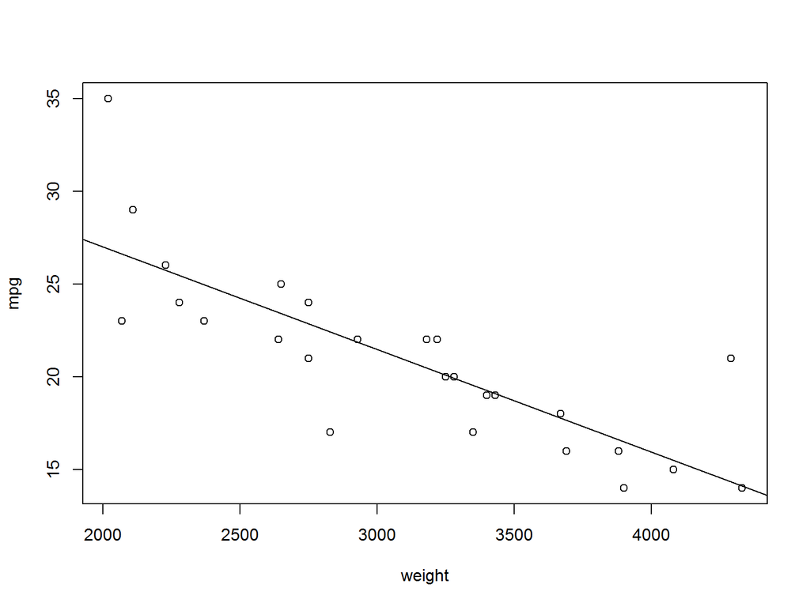

```r
# summary(lm(mpg ~ weight + length + foreign))
# Plotting data
plot (mpg ~ weight)
olsreg1 <- lm(mpg ~ weight)
abline(olsreg1)
```

```r
# Redefining variables
Y <- cbind(mpg)
X <- cbind(weight, length, foreign)
summary(Y)
```

```
##       mpg
##  Min.   :14.00
##  1st Qu.:17.25
##  Median :21.00
##  Mean   :20.92
##  3rd Qu.:23.00
##  Max.   :35.00
```

```r
summary(X)
```

```
##      weight         length         foreign
##  Min.   :2020   Min.   :163.0   Min.   :0.0000
##  1st Qu.:2642   1st Qu.:173.2   1st Qu.:0.0000
##  Median :3200   Median :191.0   Median :0.0000
##  Mean   :3099   Mean   :190.1   Mean   :0.2692
##  3rd Qu.:3610   3rd Qu.:203.0   3rd Qu.:0.7500
##  Max.   :4330   Max.   :222.0   Max.   :1.0000
```

```r
olsreg <- lm(Y ~ X)
summary(olsreg)
```

```
##
## Call:
## lm(formula = Y ~ X)
##
## Residuals:
##     Min      1Q  Median      3Q     Max
## -4.3902 -1.2734 -0.2991  0.7241  8.5203
##
## Coefficients:
##              Estimate Std. Error t value Pr(>|t|)
## (Intercept) 44.968582   9.322678   4.824 8.08e-05 ***
## Xweight     -0.005008   0.002188  -2.289    0.032 *
## Xlength     -0.043056   0.076926  -0.560    0.581
## Xforeign    -1.269211   1.632134  -0.778    0.445
## ---
## Signif. codes:  0 '***' 0.001 '**' 0.01 '*' 0.05 '.' 0.1 ' ' 1
##
## Residual standard error: 2.917 on 22 degrees of freedom
## Multiple R-squared:  0.6693, Adjusted R-squared:  0.6242
## F-statistic: 14.84 on 3 and 22 DF,  p-value: 1.673e-05
```

# Linear Regression

Linear Regression

# Panel Data Models

Panel Data Models

# Probit and Logit Models

Probit and Logit Models

# Multinomial Probit and Logit Models

Multinomial Probit and Logit Models

# Ordered Probit and Logit Models

Ordered Probit and Logit Models

# Limited Dependent Varible Models

Limited Dependent Varible Models

# Count Data Models

Count Data Models

# Survival Analysis

Survival Analysis

# Spatial Econometrics

Spatial Econometrics

# Time Series ARIMA Models

Time Series ARIMA Models